# Movielens Capstone Project

Philip Kassel

4/25/2021

```r
t <- edx[1:100000]
```

## Introduction

The purpose of this project is to improve upon the techniques described in the Movie Recommendations section of the textbook [Introduction to Data Science](https://www.routledge.com/Introduction-to-Data-Science-Data-Analysis-and-Prediction-Algorithms-with/Irizarry/p/book/9780367357986). Using actual moving ratings from the [MovieLens 10M Dataset](https://grouplens.org/datasets/movielens/), we want to design an algorithm that can predict the ratings that specific users will give to specific movies. To prevent overtraining of our model, the MovieLens data set will be split into two groups: a training set which is used to train and optimize our model and a validation set. The training set contains approximately 9 million ratings and the validation set contains approximately 1 million. Both the training set and the validation set contain the actual ratings that were given to specific movie/user combinations. The validation set, however, contains movie/user combinations that have not been seen by our model before. We can therefore compare our predicted ratings in the validation to the true ratings in order to measure how well our model performs.

To measure the performance of our model, we will calculate the residual mean squared error (RMSE) of our predictions. RMSE can be interpreted as the average error we make when predicting a rating in our validation set. The smaller the number, the better our model performs. If the RMSE is larger than 1, it means that the average prediction is more than 1 star away from the true rating, which is not good. For this project, we will aim to achieve an RMSE less than 0.86490.

## Preparing the Data

Exploring the MovieLens dataset reveals that the following rating attributes can be used to train our model: the user that gave the rating, the movie that was rated, the true rating that was given, the timestamp of when the rating occurred, and the genres that were assigned to the rated movie.

```r
t[sample(.N, 5)]
```

```
##    userId movieId rating  timestamp
## 1:    585    2344    4.0  942249796
## 2:    496    3300    1.0 1022354883
## 3:    543    2683    2.0 1049951385
## 4:    226    4007    5.0 1049905041
## 5:    543    5377    3.5 1118101872
##                                           title                          genres
## 1:                         Runaway Train (1985) Action|Adventure|Drama|Thriller
## 2:                           Pitch Black (2000)          Horror|Sci-Fi|Thriller
## 3: Austin Powers: The Spy Who Shagged Me (1999)         Action|Adventure|Comedy
## 4:                           Wall Street (1987)                           Drama
## 5:                           About a Boy (2002)                    Comedy|Drama
```

Included in the title of each rated movie is the year that the movie was released, which we can extract from the title because it might be a useful predictor. We will also measure the length of time between each movie’s release date and when each rating occurred, rounded the nearest 5 year increment.

```r
t$release_year <- str_sub(t$title,start= -6)
t$release_year <- as.numeric(str_extract(t$release_year, "\\d+"))
t$rating_year <- year(as.Date(as.POSIXct(t$timestamp,origin="1970-01-01")))
t$years_since_release <- round((t$rating_year - t$release_year) / 5) * 5

t[sample(.N, 5)]
```

```
##    userId movieId rating  timestamp                   title
## 1:    170    1240      3 1162208470  Terminator, The (1984)
## 2:     96      52      4  959875526 Mighty Aphrodite (1995)
## 3:    349     252      4  839851754             I.Q. (1994)
## 4:    773     153      2  945901195   Batman Forever (1995)
## 5:    215     376      4  948260077  River Wild, The (1994)
##                           genres release_year rating_year years_since_release
## 1:        Action|Sci-Fi|Thriller         1984        2006                  20
## 2:          Comedy|Drama|Romance         1995        2000                   5
## 3:                Comedy|Romance         1994        1996                   0
## 4: Action|Adventure|Comedy|Crime         1995        1999                   5
## 5:               Action|Thriller         1994        2000                   5
```

## Techniques

To train our model, we will first establish a baseline, *mu*, which is simply the average rating given in our training set. We will then build on this baseline by exploring how the following effects can influence a specific user’s rating of a movie: The movie itself, the user that rated the movie, the user’s genre preferences, and the time that elapsed between the release of the movie and when the rating was given.

```r
mu <- mean(t$rating)
paste("Average Movie Rating:", round(mu, 3))
```

```
## [1] "Average Movie Rating: 3.573"
```

### Movie Effect

Now that we have our baseline, we can approximate how different effects can influence how a particular movie will deviate from the average rating. For example, we know that some movies are more highly regarded than others, so we would expect for those movies to rate higher than average. Some movies are also known flops, so we would except for those movies to rate lower than average.

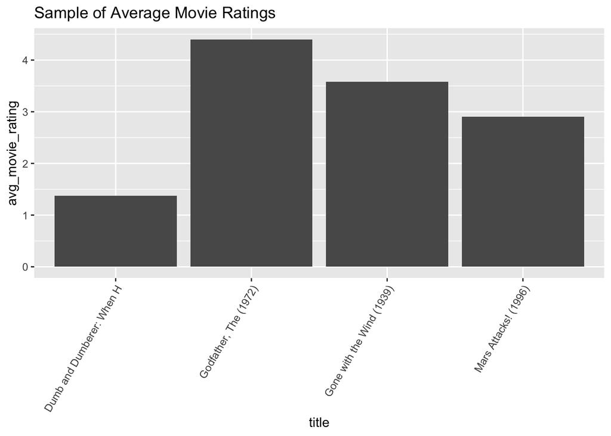

```r
titles <- c("Mars Attacks! (1996)", "Dumb and Dumberer: When Harry Met Lloyd (2003)", "Godfather, The (1972)", "Gone with the Wind (1939)", "War of the Worlds 2: The Next Wave (2008)", "Hellhounds on My Trail (1999)")
t %>% filter(title %in% titles) %>% group_by(title) %>% summarise(avg_movie_rating=mean(rating)) %>% arrange(avg_movie_rating) %>%
  mutate(title = strtrim(title, 25)) %>% ggplot(aes(title, avg_movie_rating)) + geom_bar(stat="identity") + theme(axis.text.x = element_text(angle = 60, hjust = 1)) +
  ggtitle("Sample of Average Movie Ratings")
```

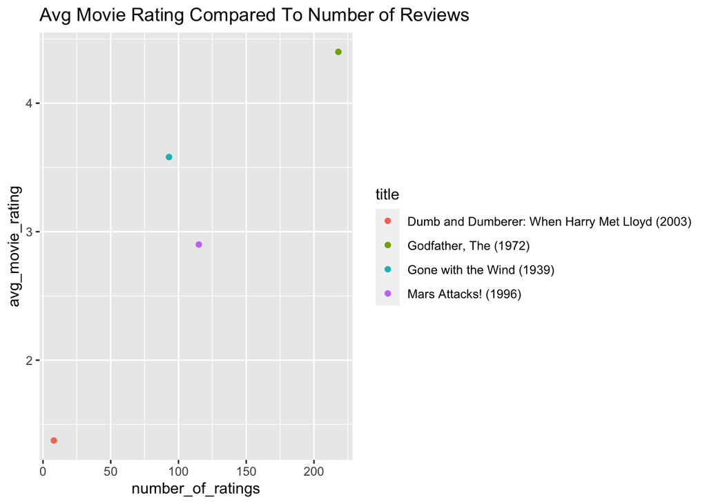

```r
t %>% filter(title %in% titles) %>% group_by(title) %>% summarise(avg_movie_rating=mean(rating), number_of_ratings = n()) %>% arrange(number_of_ratings) %>% ggplot(aes(number_of_ratings, avg_movie_rating, color=title)) + geom_point() + ggtitle("Avg Movie Rating Compared To Number of Reviews")
```

Using a technique called regularization, we can apply a new parameter, which we’ll call *lambda*, that will penalize underrated movies in order to better approximate how they might deviate from our average rating, *mu*. We’ll tune this parameter using cross-validation, so that we can find the best value for *lambda* that minimizes our RMSE score. Once *lambda* has been tuned, we can calculate the movie bias by subtracting the regularized average rating for each movie from our baseline *mu*.

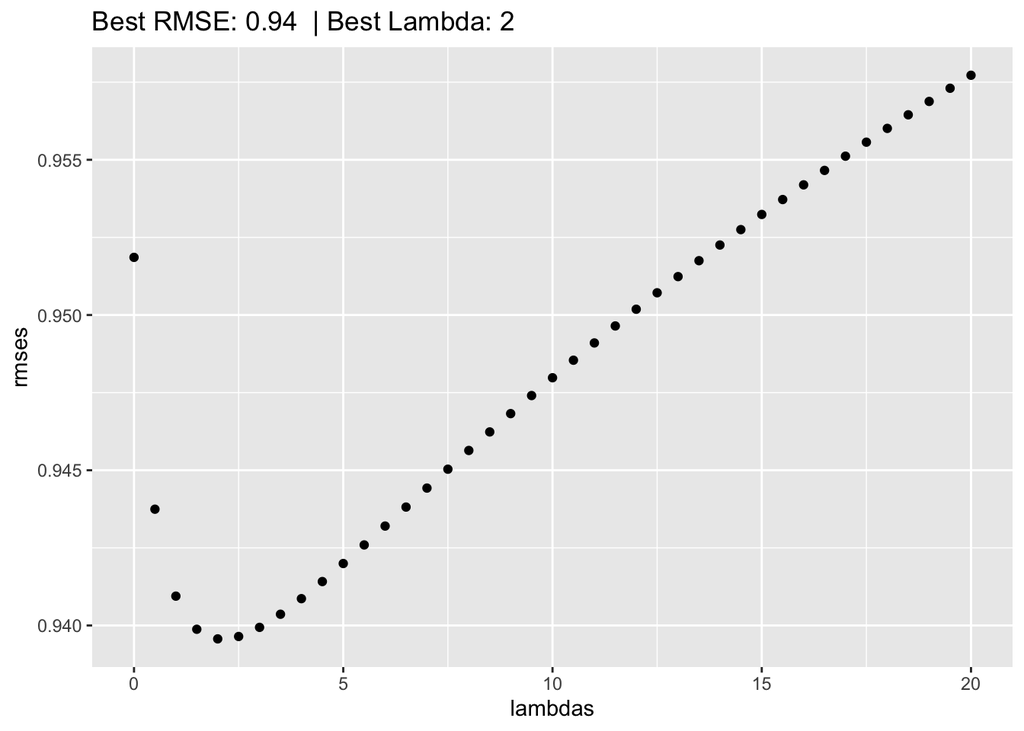

In order to make predictions about how a user might rate an unseen movie, we could simply add the known *movie_bias* to our baseline average *mu* like so: *predicted rating = movie_bias + mu*.

```
##                                       title movie_bias       mu
## 1:                         Big Night (1996)  0.6122557 3.572317
## 2:                      Shining, The (1980)  0.5281245 3.572317
## 3: Treasure of the Sierra Madre, The (1948)  0.4594779 3.572317
## 4:                        Free Willy (1993) -0.8121986 3.572317
## 5:                  American Buffalo (1996) -0.3815450 3.572317
##    predicted_rating
## 1:         4.184573
## 2:         4.100442
## 3:         4.031795
## 4:         2.760119
## 5:         3.190772
```

### User Effects

If not all movies are created equal, then it stands to reason that not all users are, either. For example, Jane may be a movie buff that rates movies more critically than John, who only watches blockbuster hits. We can, therefore, build upon our previous *movie effect*, by looking at each user’s true rating for a movie and subtracting from it that movie’s *movie_bias* and our baseline *mu*.

We will, again, use regularization and cross validation to penalize users with few ratings and to find the best value of *lambda* to minimize our RMSE.

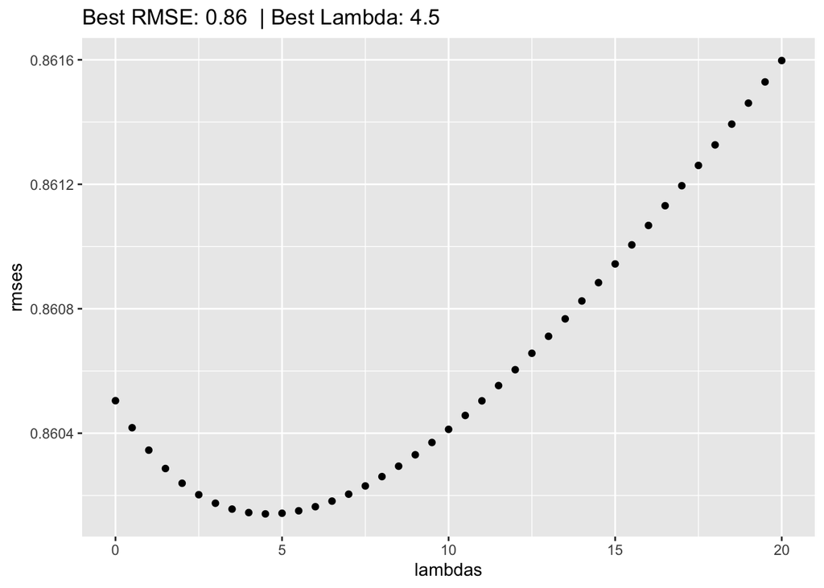

We can then predict how a user will rate an unseen movie by adding their known *user_bias* to the particular movie’s known *movie_bias* and adding that to our baseline *mu*. In other words: *predicted rating = user_bias + movie_bias + mu*.

```
##                                                       title movie_bias
## 1: Léon: The Professional (Léon) (Professional, The) (1994)  0.4205545
## 2:                                           Memento (2000)  0.7072011
## 3:                                       Zero Effect (1998) -0.1150857
## 4:                                  Don Juan DeMarco (1995)  0.1030395
## 5:                             Land Before Time, The (1988) -0.7659411
##      user_bias       mu predicted_rating
## 1:  0.06453678 3.572317         4.057409
## 2: -0.45469390 3.572317         3.824825
## 3:  0.20549578 3.572317         3.662728
## 4:  0.61365287 3.572317         4.289010
## 5: -0.32895636 3.572317         2.477420
```

### User Genres Effect

Some users prefer certain genres more than others. This effect is more challenging to approximate because many movies can be categorized into multiple genres.

```r
g <- t[sample(.N, 5)]
g
```

```
##    userId movieId rating  timestamp                             title
## 1:    171    2195    5.0 1215185779                 Dirty Work (1998)
## 2:    826    2109    3.5 1215558109                  Jerk, The (1979)
## 3:    669     589    5.0  839011650 Terminator 2: Judgment Day (1991)
## 4:    155     593    4.0 1188266376  Silence of the Lambs, The (1991)
## 5:    757    1197    5.0  869226839        Princess Bride, The (1987)
##                                     genres release_year rating_year
## 1:                                  Comedy         1998        2008
## 2:                                  Comedy         1979        2008
## 3:                           Action|Sci-Fi         1991        1996
## 4:                   Crime|Horror|Thriller         1991        2007
## 5: Action|Adventure|Comedy|Fantasy|Romance         1987        1997
##    years_since_release
## 1:                  10
## 2:                  30
## 3:                   5
## 4:                  15
## 5:                  10
```

To measure a user’s genre preferences, we will need to split each of their ratings up by their constituent genres. Below, we can see the sample ratings above broken down by genre.

```
## # A tibble: 12 x 4
##    userId rating title                             genres
##     <int>  <dbl> <chr>                             <chr>
##  1    171    5   Dirty Work (1998)                 Comedy
##  2    826    3.5 Jerk, The (1979)                  Comedy
##  3    669    5   Terminator 2: Judgment Day (1991) Action
##  4    669    5   Terminator 2: Judgment Day (1991) Sci-Fi
##  5    155    4   Silence of the Lambs, The (1991)  Crime
##  6    155    4   Silence of the Lambs, The (1991)  Horror
##  7    155    4   Silence of the Lambs, The (1991)  Thriller
##  8    757    5   Princess Bride, The (1987)        Action
##  9    757    5   Princess Bride, The (1987)        Adventure
## 10    757    5   Princess Bride, The (1987)        Comedy
## 11    757    5   Princess Bride, The (1987)        Fantasy
## 12    757    5   Princess Bride, The (1987)        Romance
```

After this is done, we can again use regularization and cross validation to calculate a specific bias that *each user has for each genre they have rated*

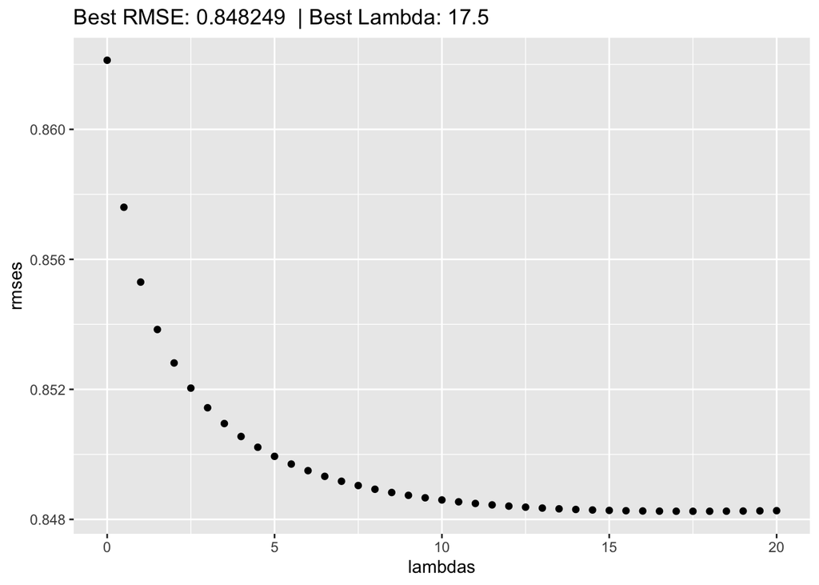

Once we have measured each user’s bias for every genre, we can then assign those genre biases to the movies in our validation set. Since one movie may have multiple genres and each genre bias was measured separately, we will calculate the average of all genre biases, which we’ll call *user_genre_bias*.

```r
train_set$user_genre_bias <- apply(X=train_set[,12:ncol(train_set)], MARGIN=1, FUN=mean, na.rm=TRUE)
train_set[sample(.N, 5)] %>% select (-timestamp, -movieId, -genres, -release_year, -years_since_release, -movie_bias, -user_bias)
```

```
##    userId rating                                      title rating_year
## 1:    621      4                    Last Detail, The (1973)        2004
## 2:    289      4                               Dogma (1999)        2000
## 3:    228      5 Rumble in the Bronx (Hont faan kui) (1995)        1996
## 4:    182      3                   Other Sister, The (1999)        2002
## 5:    517      3                  Dances with Wolves (1990)        1996
##       Action  Adventure Animation Children      Comedy      Crime       Drama
## 1:        NA         NA        NA       NA  0.11945523         NA 0.000514176
## 2:        NA 0.02584170        NA       NA -0.03612950         NA          NA
## 3: 0.1074227 0.14146840        NA       NA  0.12564942 -0.1598376          NA
## 4:        NA         NA        NA       NA -0.02274919         NA 0.034222577
## 5:        NA 0.04268023        NA       NA          NA         NA 0.095744001
##       Fantasy Musical    Romance Sci-Fi Thriller War Mystery     Western
## 1:         NA      NA         NA     NA       NA  NA      NA          NA
## 2: 0.07303481      NA         NA     NA       NA  NA      NA          NA
## 3:         NA      NA         NA     NA       NA  NA      NA          NA
## 4:         NA      NA 0.01703157     NA       NA  NA      NA          NA
## 5:         NA      NA         NA     NA       NA  NA      NA -0.05972949
##    Film-Noir Horror Documentary IMAX user_genre_bias
## 1:        NA     NA          NA   NA     0.059984701
## 2:        NA     NA          NA   NA     0.020915668
## 3:        NA     NA          NA   NA     0.053675752
## 4:        NA     NA          NA   NA     0.009501653
## 5:        NA     NA          NA   NA     0.026231582
```

```r
train_set$user_genre_bias <- apply(X=train_set[,12:ncol(train_set)], MARGIN=1, FUN=mean, na.rm=TRUE)
train_set <- train_set %>% select(-title, -genres, -timestamp, -release_year, -rating_year)
train_set$user_genre_bias <- apply(X=train_set[,6:ncol(train_set)], MARGIN=1, FUN=mean, na.rm=TRUE)
```

### Time Effect

When it comes to movies, there are warhorses that stand the test of time; classics like “Gone with the Wind” and “Citizen Kane”. Indeed, we can see a fairly strong correlation between the average rating and the length of time since a movie was released.

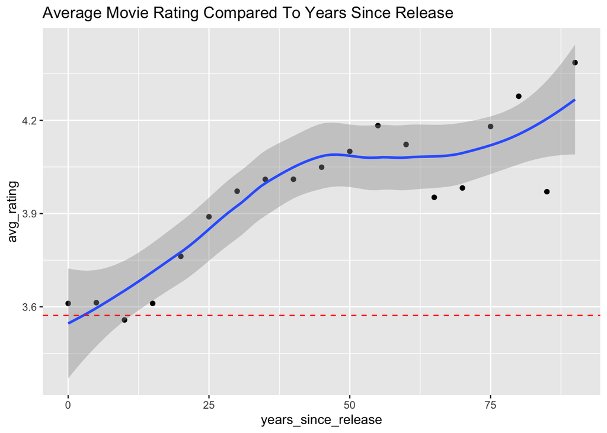

```r
t %>% group_by(years_since_release) %>% summarise(avg_rating=(sum(rating) / n() + 0.1)) %>%
  ggplot(aes(years_since_release, avg_rating)) + geom_point() + geom_smooth() + geom_hline(yintercept=mu, linetype="dashed", color = "red", size=.5) +ggtitle("Average Movie Rating Compared To Years Since Release")
```

We can also see that not every movie ages as well. Therefore, we will we measure the effect that time can have on the average rating for every movie in our dataset. We will call this final parameter *recency_bias*.

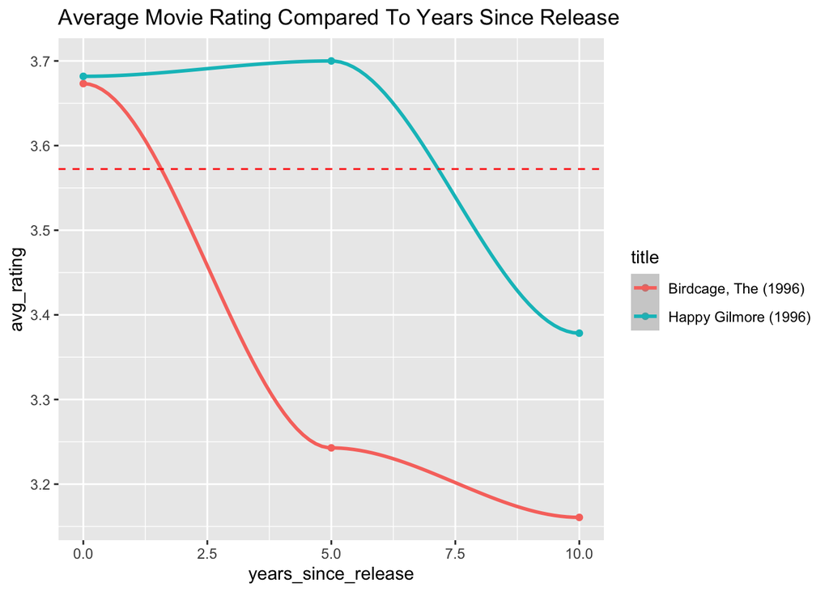

```r
t %>% filter(title %in% c("Birdcage, The (1996)", "Happy Gilmore (1996)")) %>%
  group_by(years_since_release, title) %>% summarise(avg_rating=mean(rating)) %>%
  ggplot(aes(years_since_release, avg_rating, color=title)) + geom_point() + geom_smooth() + geom_hline(yintercept=mu, linetype="dashed", color = "red", size=.5) +ggtitle("Average Movie Rating Compared To Years Since Release")
```

As we did with our previous models, we will use regularization and cross validation to tune our penalty term *lambda* to minimize our RMSE.

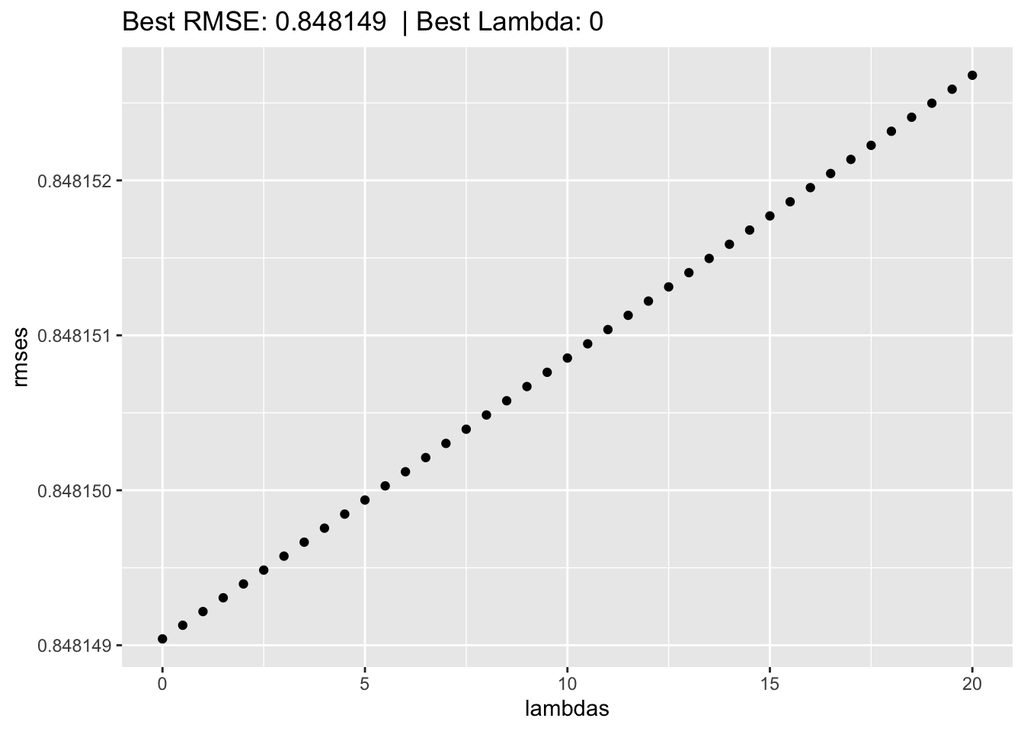

Each addition improves our score, but we seem to be approaching the limit. Now that we’ve tuned our lambda parameters, we can combine our different effects and test our model on our validation set. The lambda parameters to that will be used for each effect are:

```r
print(c(paste("Movie Lambda:", lambdas[which.min(movies_lambda)]),
paste("Users Lambda:", lambdas[which.min(users_lambda)]),
paste("User Genres Lambda:", lambdas[which.min(genres_lambda)]),
paste("Recency Lambda:", lambdas[which.min(years_since_release_lambda)])))
```

```
## [1] "Movie Lambda: 2"          "Users Lambda: 4.5"
## [3] "User Genres Lambda: 17.5" "Recency Lambda: 0"
```

Now that we have found our optimal lambda parameters, we will use them to calculate movie, user, user-genre biases on our entire training set. We can then use those biases to make predictions for the unseen movies in our validation set. The formula for our prediction is simply: *predicted rating = user_bias + movie_bias + user_genre_bias + recency_bias + mu*.

### Final Performance On Validation Set (RMSE): 0.8539283

```
##    movieId rating prediction
## 1:    8464    4.5        3.5
## 2:    4799    5.0        4.0
## 3:    6934    4.0        3.5
## 4:     227    3.0        3.0
## 5:    1092    4.0        3.5
```